# SI 618 - Homework 04: Visualization, Correlation, and Linear Models

### The total score for this assignment will be 100 points, consisting of:

- 10 pt: Overall quality of spelling, grammar, punctuation, etc. of written sentences.
- 10 pt: Code is written in [PEP 8](https://www.python.org/dev/peps/pep-0008/) style.
- 80 pt: Homework questions.

```python
MY_UNIQNAME = 'drewpap'
```

## Download the data from:

- https://www.kaggle.com/datasnaek/youtube-new

> YouTube provides a list of trending videos on it's site, determined by user interaction metrics such as likes, comments, and views. This dataset includes months of daily trending video across five different regions: the United States ("US"), Canada ("CA"), Great Britain ("GB"), Germany ("DE"), and France ("FR").
- https://www.kaggle.com/abcsds/pokemon

> This data set includes 721 Pokemon, including their number, name, first and second type, and basic stats: HP, Attack, Defense, Special Attack, Special Defense, and Speed.

```python
import pandas as pd
import numpy as np
import matplotlib.pyplot as plt
import seaborn as sns
import scipy.stats as stats
import statsmodels.api as sm
import statsmodels.formula.api as smf
%matplotlib inline
```

```python
# import the country videos and categories json
us_videos = pd.read_csv("data/USvideos.csv")
us_categories = pd.read_json("data/US_category_id.json")

gb_videos = pd.read_csv("data/GBvideos.csv")
gb_categories = pd.read_json("data/GB_category_id.json")

de_videos = pd.read_csv("data/DEvideos.csv")
de_categories = pd.read_json("data/DE_category_id.json")

ca_videos = pd.read_csv("data/CAvideos.csv")
ca_categories = pd.read_json("data/CA_category_id.json")

fr_videos = pd.read_csv("data/FRvideos.csv")
fr_categories = pd.read_json("data/FR_category_id.json")
```

## Part 1: Answer the questions below based on the *[YouTube dataset](https://www.kaggle.com/datasnaek/youtube-new)*

- Write Python code that can answer the following questions, and
- **Explain your answers in plain English.**

### Q1. For 15 Points: Compare the distributions of comments, views, likes, and dislikes

- Plot histograms for these metrics *for the US*. What can you say about them?
- Try to apply a log transformation, and plot the histograms again. How do they look now?
- Create a pairplot *for the US*, as we did in this week's lab. Do you see anything interesting?
- Create additional pairplots for the other four regions. Do they look similar?

```python
us_categories.head() # EDA
```

|  | kind | etag | items |
| --- | --- | --- | --- |
| 0 | youtube#videoCategoryListResponse | "m2yskBQFythfE4irbTIeOgYYfBU/S730Ilt-Fi-emsQJv... | {'kind': 'youtube#videoCategory', 'etag': '"m2... |
| 1 | youtube#videoCategoryListResponse | "m2yskBQFythfE4irbTIeOgYYfBU/S730Ilt-Fi-emsQJv... | {'kind': 'youtube#videoCategory', 'etag': '"m2... |
| 2 | youtube#videoCategoryListResponse | "m2yskBQFythfE4irbTIeOgYYfBU/S730Ilt-Fi-emsQJv... | {'kind': 'youtube#videoCategory', 'etag': '"m2... |
| 3 | youtube#videoCategoryListResponse | "m2yskBQFythfE4irbTIeOgYYfBU/S730Ilt-Fi-emsQJv... | {'kind': 'youtube#videoCategory', 'etag': '"m2... |
| 4 | youtube#videoCategoryListResponse | "m2yskBQFythfE4irbTIeOgYYfBU/S730Ilt-Fi-emsQJv... | {'kind': 'youtube#videoCategory', 'etag': '"m2... |

```python
us_videos.head() # EDA
```

|  | video_id | trending_date | title | channel_title | category_id | publish_time | tags | views | likes | dislikes | comment_count | thumbnail_link | comments_disabled | ratings_disabled | video_error_or_removed | description |
| --- | --- | --- | --- | --- | --- | --- | --- | --- | --- | --- | --- | --- | --- | --- | --- | --- |
| 0 | 2kyS6SvSYSE | 17.14.11 | WE WANT TO TALK ABOUT OUR MARRIAGE | CaseyNeistat | 22 | 2017-11-13T17:13:01.000Z | SHANtell martin | 748374 | 57527 | 2966 | 15954 | https://i.ytimg.com/vi/2kyS6SvSYSE/default.jpg | False | False | False | SHANTELL'S CHANNEL - https://www.youtube.com/s... |
| 1 | 1ZAPwfrtAFY | 17.14.11 | The Trump Presidency: Last Week Tonight with J... | LastWeekTonight | 24 | 2017-11-13T07:30:00.000Z | last week tonight trump presidency\|"last week ... | 2418783 | 97185 | 6146 | 12703 | https://i.ytimg.com/vi/1ZAPwfrtAFY/default.jpg | False | False | False | One year after the presidential election, John... |
| 2 | 5qpjK5DgCt4 | 17.14.11 | Racist Superman \| Rudy Mancuso, King Bach & Le... | Rudy Mancuso | 23 | 2017-11-12T19:05:24.000Z | racist superman\|"rudy"\|"mancuso"\|"king"\|"bach"... | 3191434 | 146033 | 5339 | 8181 | https://i.ytimg.com/vi/5qpjK5DgCt4/default.jpg | False | False | False | WATCH MY PREVIOUS VIDEO ▶ \n\nSUBSCRIBE ► http... |
| 3 | puqaWrEC7tY | 17.14.11 | Nickelback Lyrics: Real or Fake? | Good Mythical Morning | 24 | 2017-11-13T11:00:04.000Z | rhett and link\|"gmm"\|"good mythical morning"\|"... | 343168 | 10172 | 666 | 2146 | https://i.ytimg.com/vi/puqaWrEC7tY/default.jpg | False | False | False | Today we find out if Link is a Nickelback amat... |
| 4 | d380meD0W0M | 17.14.11 | I Dare You: GOING BALD!? | nigahiga | 24 | 2017-11-12T18:01:41.000Z | ryan\|"higa"\|"higatv"\|"nigahiga"\|"i dare you"\|"... | 2095731 | 132235 | 1989 | 17518 | https://i.ytimg.com/vi/d380meD0W0M/default.jpg | False | False | False | I know it's been a while since we did this sho... |

Some of the cells have zeroes because of the settings applied to the videos and others have errors or are removed. These zeroes misrepresent the data because they are not being tracked, so we ought to remove them for our analysis. To do so I created this function that removes errors and filters out any videos where the comments, likes, and dislikes have been turned off.

```python
def drop_zeroes_and_errors(youtube_dataset):
    ''' Returns a DF where no videos have errors, comments disabled,
        or ratings disabled

        Parameters
        ----------
        youtube_dataset : pandas.DataFrame
            A data frame containing comments_disabled, ratings_disabled_,
            and video_error_or_removed, columns with boolean values

        Returns
        -------
        youtube_dataset : pandas.DataFrame
            A data frame where comments_disabled, ratings_disabled_,
            and video_error_or_removed columns only have false values

    '''

    return youtube_dataset[(youtube_dataset["comments_disabled"] == False) &      # Remove videos with disabled comments
                           (youtube_dataset["ratings_disabled"] == False) &       # Remove videos with disabled ratings
                           (youtube_dataset["video_error_or_removed"] == False)]  # Remove removed/error videos
```

Applying the function, we get a clean data frame. From there, lets make a new data frame from the cleaned one only containing the values we want.

```python
us_videos_disabled_col_removed = drop_zeroes_and_errors(us_videos)

coms_views_likes_dislikes = us_videos_disabled_col_removed[["comment_count","views","likes","dislikes"]]
```

Getting a feel for the data with describe, we see a huge range of values. I've converted it to integer form for readability. Due to the large range of data, the histograms we create will likely not show very much.

```python
coms_views_likes_dislikes.describe().astype(int)
```

|  | comment_count | views | likes | dislikes |
| --- | --- | --- | --- | --- |
| count | 40230 | 40230 | 40230 | 40230 |
| mean | 8594 | 2360888 | 75228 | 3734 |
| std | 37746 | 7416465 | 230754 | 29272 |
| min | 0 | 549 | 0 | 0 |
| 25% | 654 | 244281 | 5634 | 207 |
| 50% | 1919 | 683300 | 18340 | 635 |
| 75% | 5900 | 1820257 | 56064 | 1935 |
| max | 1361580 | 225211923 | 5613827 | 1674420 |

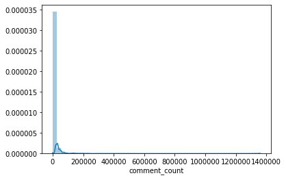

```python
# Comment count hist
sns.distplot(coms_views_likes_dislikes["comment_count"])
```

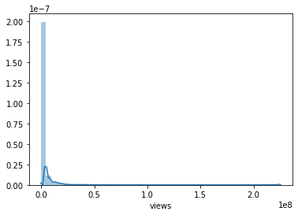

```python
# Views hist
sns.distplot(coms_views_likes_dislikes["views"])
```

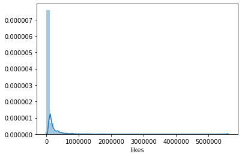

```python
# Likes hist
sns.distplot(coms_views_likes_dislikes["likes"])
```

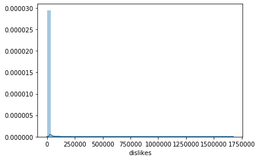

```python
# Dislikes hist
sns.distplot(coms_views_likes_dislikes["dislikes"])
```

These histograms are not showing much at all. The reason is that the bins are far too large and the range of values that we have is so large it is difficult to slice the data into visually representable chunks. We either need far more bins, a smaller portion of the data set, or another method to change the values so that they may be represented more easily. Let's perform a log transformation on the data and re plot the histograms to see if that will give us more insight.

```python
log_transformed = coms_views_likes_dislikes.apply(lambda x: np.log(x)).replace([-np.inf, np.inf], np.nan) # log transform and replace inf with NaN
log_transformed
```

|  | comment_count | views | likes | dislikes |
| --- | --- | --- | --- | --- |
| 0 | 9.677465 | 13.525658 | 10.960010 | 7.994970 |
| 1 | 9.449593 | 14.698775 | 11.484372 | 8.723557 |
| 2 | 9.009570 | 14.975981 | 11.891588 | 8.582794 |
| 3 | 7.671361 | 12.745975 | 9.227394 | 6.501290 |
| 4 | 9.770984 | 14.555413 | 11.792336 | 7.595387 |
| ... | ... | ... | ... | ... |
| 40944 | 7.884953 | 14.337637 | 10.549543 | 7.233455 |
| 40945 | 8.277920 | 13.878296 | 11.002233 | 5.945421 |
| 40946 | 8.292048 | 13.879847 | 10.780372 | 6.939254 |
| 40947 | 9.479451 | 15.549078 | 12.170223 | 7.953670 |
| 40948 | 11.883074 | 16.148248 | 12.785712 | 12.268935 |

40230 rows × 4 columns

In addition to this log transformation, I've replaced any values that went to negative or positive infinity with NaN. These were likely produced by taking the log(0). It's important to know how much this is going to affect our data, so in addition to plotting the histograms of the log transformed data, I included a print statement showing what portion of the data was removed. In each case, less than 1% of the results were removed, so getting rid of these data points is likely not going to change our distribution very much.

```
99.51% of values are greater than 0
```

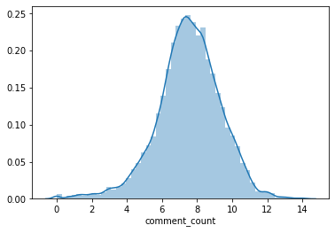

```python
print(f'{round((len(log_transformed[log_transformed["comment_count"] > 0]) / len(log_transformed["comment_count"])) * 100, 2)}% of values are greater than 0')
sns.distplot(log_transformed["comment_count"].dropna())
```

```
100.0% of values are greater than 0
```

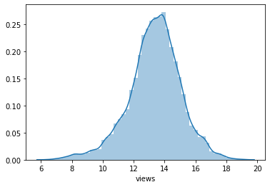

```python
print(f'{round((len(log_transformed[log_transformed["views"] > 0]) / len(log_transformed["views"])) * 100, 2)}% of values are greater than 0')
sns.distplot(log_transformed["views"].dropna())
```

```
99.97% of values are greater than 0
```

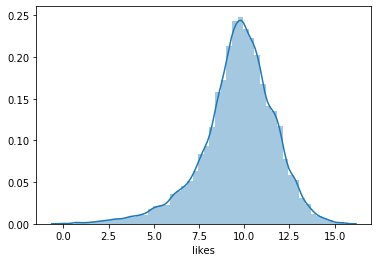

```python
print(f'{round((len(log_transformed[log_transformed["likes"] > 0]) / len(log_transformed["likes"])) * 100, 2)}% of values are greater than 0')
sns.distplot(log_transformed["likes"].dropna())
```

```
99.09% of values are greater than 0
```

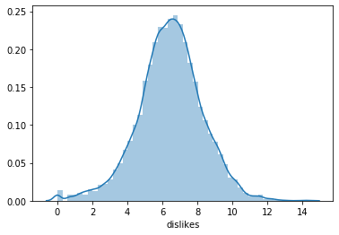

```python
print(f'{round((len(log_transformed[log_transformed["dislikes"] > 0]) / len(log_transformed["dislikes"])) * 100, 2)}% of values are greater than 0')
sns.distplot(log_transformed["dislikes"].dropna())
```

Next, let's examine a pairplot of US values to see what we can find. Given that we know that the histograms will not display well without a log transformation, before showing the pairplot let's do a log transformation on the values like we did before:

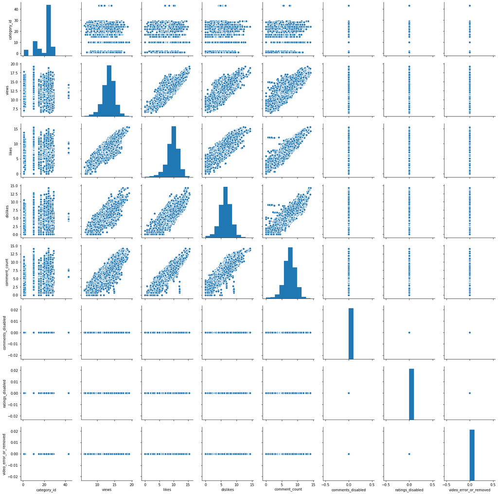

```python
us_cleaned_log_transformed = us_videos_disabled_col_removed.copy()
us_cleaned_log_transformed[["views","likes","dislikes","comment_count"]] = us_cleaned_log_transformed[["views","likes","dislikes","comment_count"]].apply(lambda x: np.log(x)).replace([-np.inf, np.inf], np.nan)
sns.pairplot(us_cleaned_log_transformed)
```

Looking at the pair plots, it appears that many of the values we log transformed tend to have a relatively linear relationship. There are a couple of interesting outliers where likes and dislikes meet with comment count. However, the most interesting information gleaned from this pairplot is the distribution of category IDs. There is significant clustering between IDs 20-25. This calls into question some of the statistics we saw in the EDA as some categories may be overrepresented. Their associated likes, dislikes, views, and comment counts may be overpowering other categories included within the set. However without knowing what those categories are, it's difficult to say why there are so many included. Maybe this category is the broadest of the bunch? Maybe this is the most popular on YouTube? There are multiple explanations that all require further analysis to understand what is happening.

Now let's look at some pairplots of the other countries and see if they look different from the US. Again, I've log transformed the views, likes, dislikes, and comment count columns.

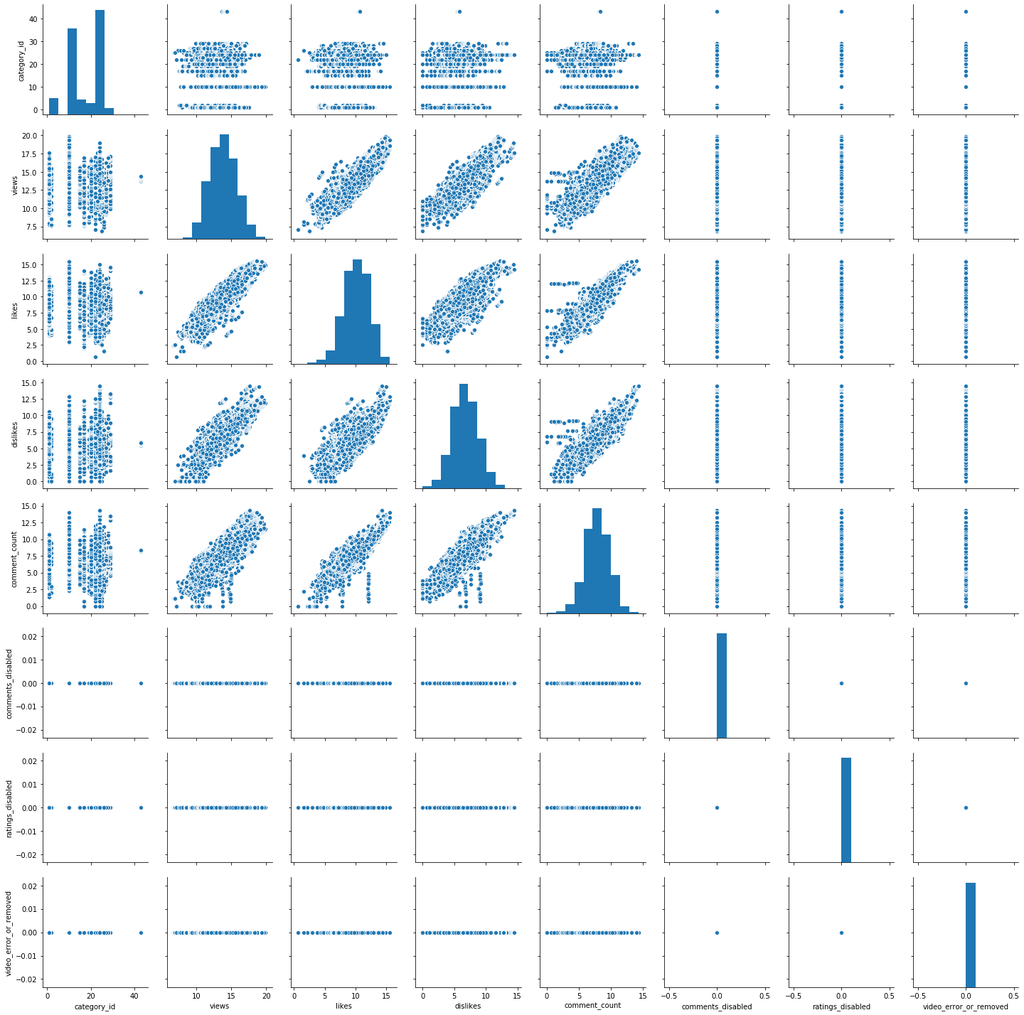

```python
gb_videos_cleaned = drop_zeroes_and_errors(gb_videos)

gb_cleaned_log_transformed = gb_videos_cleaned.copy()
gb_cleaned_log_transformed[["views","likes","dislikes","comment_count"]] = gb_cleaned_log_transformed[["views","likes","dislikes","comment_count"]].apply(lambda x: np.log(x)).replace([-np.inf, np.inf], np.nan)

sns.pairplot(gb_cleaned_log_transformed)
```

Great Britain's pairplot looks very similar to the US. There are similar outliers in the likes and dislikes columns when correlated with comment count. However, the biggest difference is the categories represented. The distribution of category IDs looks biomdal. It's interesting seeing that there is a more diverse array of categories represented, yet the pairplots look very similar. Maybe this speaks to the nature of views, likes, comments, and dislikes on YouTube instead of the country viewing the video.

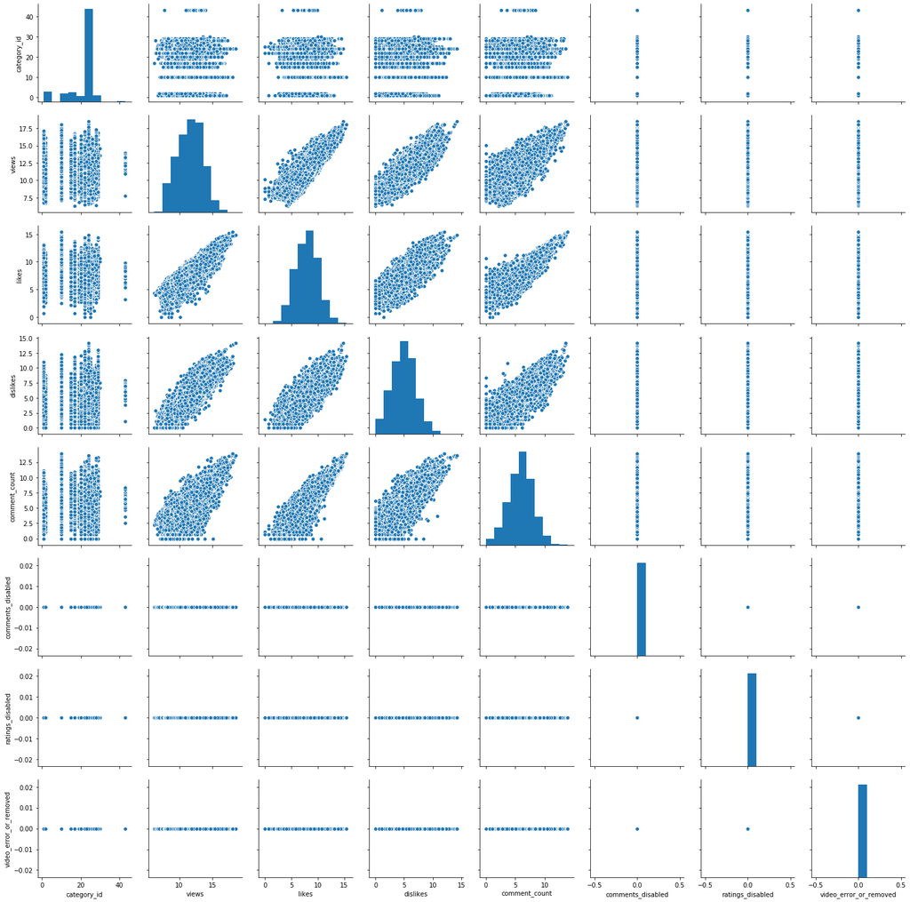

```python
de_videos_cleaned = drop_zeroes_and_errors(de_videos)

de_cleaned_log_transformed = de_videos_cleaned.copy()
de_cleaned_log_transformed[["views","likes","dislikes","comment_count"]] = de_cleaned_log_transformed[["views","likes","dislikes","comment_count"]].apply(lambda x: np.log(x)).replace([-np.inf, np.inf], np.nan)

sns.pairplot(de_cleaned_log_transformed)
```

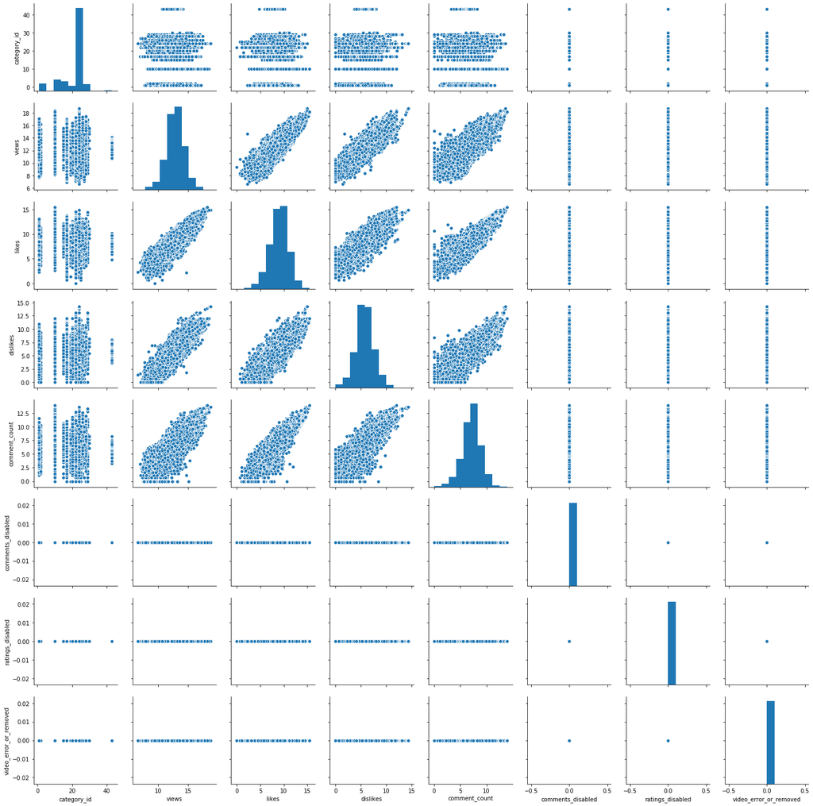

```python
ca_videos_cleaned = drop_zeroes_and_errors(ca_videos)

ca_cleaned_log_transformed = ca_videos_cleaned.copy()
ca_cleaned_log_transformed[["views","likes","dislikes","comment_count"]] = ca_cleaned_log_transformed[["views","likes","dislikes","comment_count"]].apply(lambda x: np.log(x)).replace([-np.inf, np.inf], np.nan)

sns.pairplot(ca_cleaned_log_transformed)
```

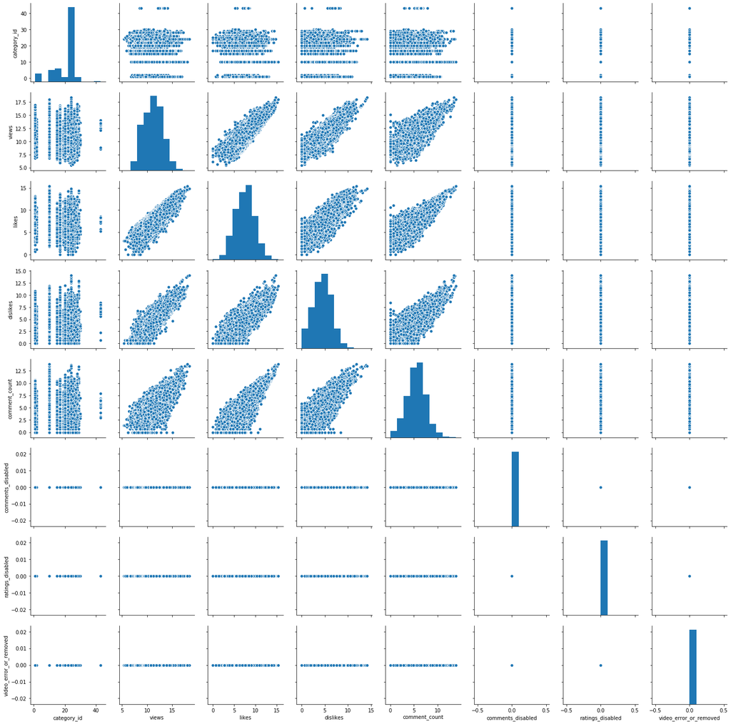

```python
fr_videos_cleaned = drop_zeroes_and_errors(fr_videos)

fr_cleaned_log_transformed = fr_videos_cleaned.copy()
fr_cleaned_log_transformed[["views","likes","dislikes","comment_count"]] = fr_cleaned_log_transformed[["views","likes","dislikes","comment_count"]].apply(lambda x: np.log(x)).replace([-np.inf, np.inf], np.nan)

sns.pairplot(fr_cleaned_log_transformed)
```

Canada, Germany, and France all look slightly different from the US and Great Britain. The scatterplots are slightly wider than the others, indicating a flatter distribution of views, likes, comments, and dislikes.

### Q2. For 10 Points: Create a heatmap of correlations between the variables for a region of your choice

> A [heat map (or heatmap)](https://en.wikipedia.org/wiki/Heat_map) is a graphical representation of data where the individual values contained in a matrix are represented as colors.

Seaborn makes it easy to create a heatmap with [`seaborn.heatmap()`](https://seaborn.pydata.org/generated/seaborn.heatmap.html)

- Create a correlation matrix for your numeric variables using Pandas with [`DataFrame.corr()`](https://pandas.pydata.org/pandas-docs/stable/generated/pandas.DataFrame.corr.html). That is, if your dataframe is called `df`, use `df.corr()`.
- Pass in your correlation matrix to `seaborn.heatmap()`, and annotate it with the parameter `annot=True`.
- Are there any interesting correlations? What are they?

```
(4.0, 0.0)
```

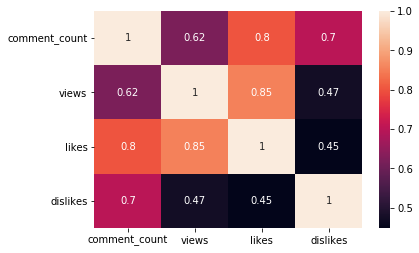

```python
us_numeric_vars_corr_matrix = coms_views_likes_dislikes.corr()
ax = sns.heatmap(us_numeric_vars_corr_matrix, annot = True) # Fix bottoms getting cut off
bottom, top = ax.get_ylim()                                 # https://stackoverflow.com/questions/56942670/matplotlib-seaborn-first-and-last-row-cut-in-half-of-heatmap-plot
ax.set_ylim(bottom + 0.5, top - 0.5)
```

The most interesting correlations in this heatmap are the correlations between views and dislikes and between views and likes. The 0.85 correlation between views and likes indicates that the number of views is a relatively good predictor for the number of likes on a video. This is in stark contrast with views and dislikes. A 0.47 correlation means that views is not a strong predictor of dislikes for any given video.

The other correlations are less interesting in my opinion. Views and comment counts is not surprising given my own behavior on YouTube. It is easy to imagine that many users merely watch videos and move on as opposed to taking the time to leave a comment. Likes not correlating with dislikes is unsurprising as a user can only choose to do one of the two, so they are at odds with one another. Dislikes and comment count are also unsurprising, even though there is a fair correlation (0.7). The reason I find this unsurprising is because it is not difficult to imagine the psychology of a user who dislikes a video. The negative feeling of a dislike may not be enough of an expression of their distaste, so they are more likely to leave a comment to release that emotion. Compare a negative video to a more neutral video where not a lot of emotion is evoked and you'd likely see users passing by without commenting.

### Q3. For 15 points: Create and compare OLS models using variables of your choice, for a region of your choice

- Use statsmodels to perform an ANOVA (categorical regression) of a variable of your choice as the dependent variable (for example, views) and the video category as the independent variable.
- Provide your interpretation of the results.
- Create two different regression models where the dependent variables are the same, and the independent variables are different. What does your interpretation say about the two models?

```python
us_videos_cat_id_com_count = us_videos_disabled_col_removed[["category_id", "comment_count"]] # Get category ID and comment count

us_cat_ids = us_categories["items"].apply(lambda x: x["id"]).to_frame().rename(columns = {"items" :"category_id"}) # Get IDs from imported json
us_cat_titles =us_categories["items"].apply(lambda x: x["snippet"]["title"]).to_frame() # Get category titles from json

us_id_and_category = pd.concat([us_cat_ids, us_cat_titles], axis = 1) #Create df of the titles and categories
us_id_and_category["category_id"] = us_id_and_category["category_id"].apply(lambda x: int(x))

# Add the new categories to the ID with a left merge
merged = us_videos_cat_id_com_count.merge(us_id_and_category, how = "left").rename(columns = {"items":"category"})

us_category_comment_count = merged[["category", "comment_count"]]
us_category_comment_count # Get new DF from the merged frame

anova_cat_com_count = smf.ols("comment_count ~ C(category)", data = us_category_comment_count).fit()
anova_cat_com_count.summary()
```

OLS Regression Results

| Dep. Variable: | comment_count | R-squared: | 0.026 |
| --- | --- | --- | --- |
| Model: | OLS | Adj. R-squared: | 0.026 |
| Method: | Least Squares | F-statistic: | 71.98 |
| Date: | Sun, 23 Feb 2020 | Prob (F-statistic): | 1.10e-217 |
| Time: | 19:29:23 | Log-Likelihood: | -4.8052e+05 |
| No. Observations: | 40230 | AIC: | 9.611e+05 |
| Df Residuals: | 40214 | BIC: | 9.612e+05 |
| Df Model: | 15 |  |  |
| Covariance Type: | nonrobust |  |  |

|  | coef | std err | t | P>\|t\| | [0.025 | 0.975] |
| --- | --- | --- | --- | --- | --- | --- |
| Intercept | 2104.4824 | 1939.521 | 1.085 | 0.278 | -1697.023 | 5905.988 |
| C(category)[T.Comedy] | 4421.0117 | 2040.466 | 2.167 | 0.030 | 421.651 | 8420.372 |
| C(category)[T.Education] | 1205.8102 | 2146.176 | 0.562 | 0.574 | -3000.745 | 5412.365 |
| C(category)[T.Entertainment] | 5438.5556 | 1975.885 | 2.752 | 0.006 | 1565.775 | 9311.336 |
| C(category)[T.Film & Animation] | 5651.9574 | 2089.256 | 2.705 | 0.007 | 1556.967 | 9746.948 |
| C(category)[T.Gaming] | 1.612e+04 | 2340.415 | 6.886 | 0.000 | 1.15e+04 | 2.07e+04 |
| C(category)[T.Howto & Style] | 3493.9578 | 2024.211 | 1.726 | 0.084 | -473.543 | 7461.459 |
| C(category)[T.Music] | 1.732e+04 | 1994.254 | 8.687 | 0.000 | 1.34e+04 | 2.12e+04 |
| C(category)[T.News & Politics] | 506.5998 | 2088.507 | 0.243 | 0.808 | -3586.923 | 4600.122 |
| C(category)[T.Nonprofits & Activism] | 8.863e+04 | 5472.840 | 16.194 | 0.000 | 7.79e+04 | 9.94e+04 |
| C(category)[T.People & Blogs] | 5807.3949 | 2050.663 | 2.832 | 0.005 | 1788.049 | 9826.741 |
| C(category)[T.Pets & Animals] | 800.2174 | 2297.197 | 0.348 | 0.728 | -3702.342 | 5302.777 |
| C(category)[T.Science & Technology] | 3085.9544 | 2088.694 | 1.477 | 0.140 | -1007.934 | 7179.843 |
| C(category)[T.Shows] | -435.7631 | 5302.270 | -0.082 | 0.935 | -1.08e+04 | 9956.807 |
| C(category)[T.Sports] | 3125.4195 | 2100.090 | 1.488 | 0.137 | -990.805 | 7241.644 |
| C(category)[T.Travel & Events] | 162.9579 | 2686.016 | 0.061 | 0.952 | -5101.695 | 5427.611 |

| Omnibus: | 87223.714 | Durbin-Watson: | 1.979 |
| --- | --- | --- | --- |
| Prob(Omnibus): | 0.000 | Jarque-Bera (JB): | 480558769.639 |
| Skew: | 19.645 | Prob(JB): | 0.00 |
| Kurtosis: | 536.988 | Cond. No. | 46.3 |

Warnings:  
[1] Standard Errors assume that the covariance matrix of the errors is correctly specified.

In the above OLS regression, I used comment_count as the dependent variable and performed an ANOVA with category as the independent variable for YouTube videos in the US. I brought in the categories from the associated JSON file and mapped them to their associated IDs before performing the regression.

Interpreting this, we can see that several categories have p values of less than 0.05, indicating that the variance within that category is not by chance. Others, which are above the 0.05 cutoff, cannot determine whether their variance in comment count is due to chance or due to a relationship to the observed category. Overall, however, only 2.6% of the total variance is explained, which means this model, despite having significant results, is not likely to be a great predictor of overall variance in comment counts.

```python
# Linear regression model 1
model1 = smf.ols("comment_count ~ likes", data = us_videos_disabled_col_removed).fit()
model1.summary()
```

OLS Regression Results

| Dep. Variable: | comment_count | R-squared: | 0.645 |
| --- | --- | --- | --- |
| Model: | OLS | Adj. R-squared: | 0.645 |
| Method: | Least Squares | F-statistic: | 7.305e+04 |
| Date: | Sun, 23 Feb 2020 | Prob (F-statistic): | 0.00 |
| Time: | 19:29:23 | Log-Likelihood: | -4.6023e+05 |
| No. Observations: | 40230 | AIC: | 9.205e+05 |
| Df Residuals: | 40228 | BIC: | 9.205e+05 |
| Df Model: | 1 |  |  |
| Covariance Type: | nonrobust |  |  |

|  | coef | std err | t | P>\|t\| | [0.025 | 0.975] |
| --- | --- | --- | --- | --- | --- | --- |
| Intercept | -1287.6695 | 117.958 | -10.916 | 0.000 | -1518.870 | -1056.469 |
| likes | 0.1314 | 0.000 | 270.285 | 0.000 | 0.130 | 0.132 |

| Omnibus: | 93262.749 | Durbin-Watson: | 1.980 |
| --- | --- | --- | --- |
| Prob(Omnibus): | 0.000 | Jarque-Bera (JB): | 1469623287.993 |
| Skew: | 22.607 | Prob(JB): | 0.00 |
| Kurtosis: | 938.248 | Cond. No. | 2.55e+05 |

Warnings:  
[1] Standard Errors assume that the covariance matrix of the errors is correctly specified.  
[2] The condition number is large, 2.55e+05. This might indicate that there are  
strong multicollinearity or other numerical problems.

```python
# Linear regression model 2
model2 = smf.ols("comment_count ~ views", data = us_videos_disabled_col_removed).fit()
model2.summary()
```

OLS Regression Results

| Dep. Variable: | comment_count | R-squared: | 0.386 |
| --- | --- | --- | --- |
| Model: | OLS | Adj. R-squared: | 0.386 |
| Method: | Least Squares | F-statistic: | 2.532e+04 |
| Date: | Sun, 23 Feb 2020 | Prob (F-statistic): | 0.00 |
| Time: | 19:29:23 | Log-Likelihood: | -4.7123e+05 |
| No. Observations: | 40230 | AIC: | 9.425e+05 |
| Df Residuals: | 40228 | BIC: | 9.425e+05 |
| Df Model: | 1 |  |  |
| Covariance Type: | nonrobust |  |  |

|  | coef | std err | t | P>\|t\| | [0.025 | 0.975] |
| --- | --- | --- | --- | --- | --- | --- |
| Intercept | 1126.5244 | 154.724 | 7.281 | 0.000 | 823.262 | 1429.787 |
| views | 0.0032 | 1.99e-05 | 159.120 | 0.000 | 0.003 | 0.003 |

| Omnibus: | 87877.637 | Durbin-Watson: | 1.972 |
| --- | --- | --- | --- |
| Prob(Omnibus): | 0.000 | Jarque-Bera (JB): | 642683432.709 |
| Skew: | 19.847 | Prob(JB): | 0.00 |
| Kurtosis: | 620.924 | Cond. No. | 8.17e+06 |

Warnings:  
[1] Standard Errors assume that the covariance matrix of the errors is correctly specified.  
[2] The condition number is large, 8.17e+06. This might indicate that there are  
strong multicollinearity or other numerical problems.

My interpretation of the previous model fits well with the two observed models. In both models, the dependent variable was comment_count, which was also the dependent variable in the ANOVA. In both models, a higher R-squared is observed; 0.645 for likes and 0.386 for views. If there was room for more explanation of the variance, which there was, we would hope to find it in other variables measured in the data. Fortunately, we see more explanatory power regarding variance from the relationship between comment count and likes and also from the relationship between commment count and views. Both models were statistically significant with p values under the 0.05 threshold.

## Part 2: Answer the questions below based on the *[Pokémon dataset](https://www.kaggle.com/abcsds/pokemon)* </span>

- Write Python code that can answer the following questions, and
- Explain your answers in plain English.

```python
pokemon_data = pd.read_csv("data/Pokemon.csv")
pokemon_data
```

|  | # | Name | Type 1 | Type 2 | Total | HP | Attack | Defense | Sp. Atk | Sp. Def | Speed | Generation | Legendary |
| --- | --- | --- | --- | --- | --- | --- | --- | --- | --- | --- | --- | --- | --- |
| 0 | 1 | Bulbasaur | Grass | Poison | 318 | 45 | 49 | 49 | 65 | 65 | 45 | 1 | False |
| 1 | 2 | Ivysaur | Grass | Poison | 405 | 60 | 62 | 63 | 80 | 80 | 60 | 1 | False |
| 2 | 3 | Venusaur | Grass | Poison | 525 | 80 | 82 | 83 | 100 | 100 | 80 | 1 | False |
| 3 | 3 | VenusaurMega Venusaur | Grass | Poison | 625 | 80 | 100 | 123 | 122 | 120 | 80 | 1 | False |
| 4 | 4 | Charmander | Fire | NaN | 309 | 39 | 52 | 43 | 60 | 50 | 65 | 1 | False |
| ... | ... | ... | ... | ... | ... | ... | ... | ... | ... | ... | ... | ... | ... |
| 795 | 719 | Diancie | Rock | Fairy | 600 | 50 | 100 | 150 | 100 | 150 | 50 | 6 | True |
| 796 | 719 | DiancieMega Diancie | Rock | Fairy | 700 | 50 | 160 | 110 | 160 | 110 | 110 | 6 | True |
| 797 | 720 | HoopaHoopa Confined | Psychic | Ghost | 600 | 80 | 110 | 60 | 150 | 130 | 70 | 6 | True |
| 798 | 720 | HoopaHoopa Unbound | Psychic | Dark | 680 | 80 | 160 | 60 | 170 | 130 | 80 | 6 | True |
| 799 | 721 | Volcanion | Fire | Water | 600 | 80 | 110 | 120 | 130 | 90 | 70 | 6 | True |

800 rows × 13 columns

### Q4. For 10 Points: Plot the pairs of different ability points (HP, Attack, Sp. Attack, Defense, etc.).

- Which pairs have the most/least correlation coefficients?

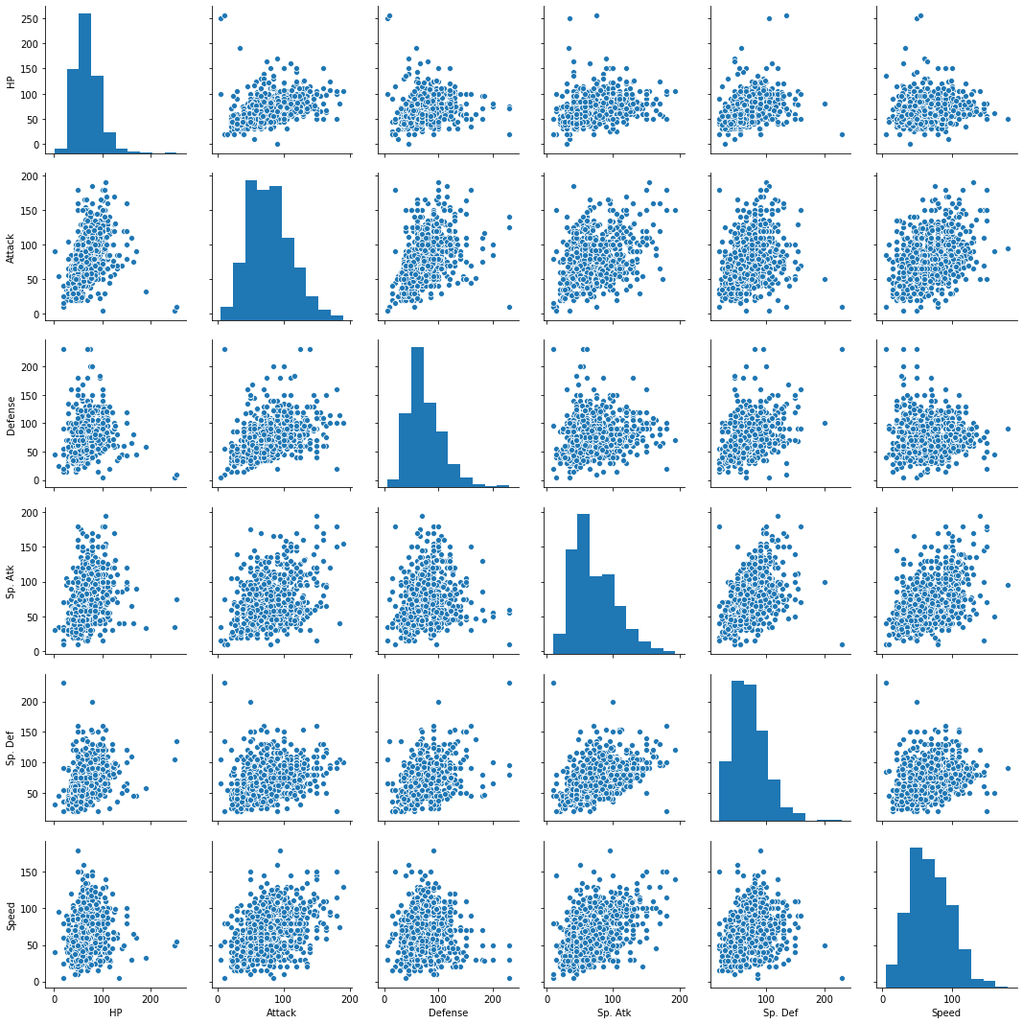

```python
pokemon_ability_cols = pokemon_data[["HP", "Attack","Defense","Sp. Atk", "Sp. Def", "Speed"]]
sns.pairplot(pokemon_ability_cols)
```

```python
pokemon_ability_cols.corr()
```

|  | HP | Attack | Defense | Sp. Atk | Sp. Def | Speed |
| --- | --- | --- | --- | --- | --- | --- |
| HP | 1.000000 | 0.422386 | 0.239622 | 0.362380 | 0.378718 | 0.175952 |
| Attack | 0.422386 | 1.000000 | 0.438687 | 0.396362 | 0.263990 | 0.381240 |
| Defense | 0.239622 | 0.438687 | 1.000000 | 0.223549 | 0.510747 | 0.015227 |
| Sp. Atk | 0.362380 | 0.396362 | 0.223549 | 1.000000 | 0.506121 | 0.473018 |
| Sp. Def | 0.378718 | 0.263990 | 0.510747 | 0.506121 | 1.000000 | 0.259133 |
| Speed | 0.175952 | 0.381240 | 0.015227 | 0.473018 | 0.259133 | 1.000000 |

Given the correlations above, the strongest correlations are between Sp. Def and Defense (0.510747) and between Sp. Def and Sp. Attack (0.506121). The weakest correlations are between Speed and Defense (0.015227) and between Speed and HP (0.175952). However, none of the values correlate above 0.55, indicating that even the stronger correlations between ability types are tenuous at best.

### Q5. For 15 Points: Plot the distribution of ability points per Pokémon type

- How would you describe each Pokémon type with different ability points?

First, let's create a new data frame with only the abilities and pokemon types.

```python
types_and_abilities = pokemon_data[["Type 1", "Type 2", "Total", "HP", "Attack", "Defense", "Sp. Atk", "Sp. Def", "Speed"]]
```

Having some background with Pokemon games, I know that no Pokemon are typeless, but it is possible for Pokemon to have only one type. Let's check and see if both fields contain NaN values. If both have NaN values we will need to clean the data before analyzing them.

```python
print(types_and_abilities["Type 1"].isnull().values.any()) #Check if any values are NaN
print(types_and_abilities["Type 2"].isnull().values.any())
```

```
False
True
```

From our check, we can see that there are no NaN values in the type 1 column, but there are in type 2. Where the NaN values are present, we know that that Pokemon only has one type. Therefore, we should not throw away the row and include it in our analysis. However, analyzing Pokemon by their types is a difficult task as there are two possible approaches. One approach would be to consider Pokemon types by their combined type 1 and type 2 traits as many of their weaknesses are determined by their types. However, this will result in many rows where there are only one or two data points, so performing statistical analysis on these combined types is not worth it as it is not representative of the type overall.

The other approach, which is the one that I've elected to do, is to split the pokemon by type 1 and type 2 and consider them as if they were only one type. This means that the stats of Pokemon with two types will have more weight on the data as their stats will be considered twice; once for their primary type and twice for their secondary type. Pokemon without a second type will be removed from the data as their type 2 will come up as NaN values. Regardless, I believe this approach is better than the first as it will allow us to get a broader view of the distribution of stats per type.

```python
type_one_only = types_and_abilities.loc[:, types_and_abilities.columns != "Type 2"]
type_two_only = types_and_abilities.loc[:, types_and_abilities.columns != "Type 1"]

type_one_only = type_one_only.copy()
type_one_only.rename(columns = {"Type 1" : "Type"}, inplace = True)
type_one_only

type_two_only = type_two_only.copy()
type_two_only.rename(columns = {"Type 2" : "Type"}, inplace = True)
type_two_only

means_by_pokemon_type = pd.concat([type_one_only, type_two_only]).dropna().groupby("Type").mean()
means_by_pokemon_type.sort_values(by = "Total", ascending = False, inplace = True)
means_by_pokemon_type
```

| Type | Total | HP | Attack | Defense | Sp. Atk | Sp. Def | Speed |
| --- | --- | --- | --- | --- | --- | --- | --- |
| Dragon | 541.760000 | 82.900000 | 105.760000 | 86.620000 | 97.440000 | 86.900000 | 82.140000 |
| Steel | 486.591837 | 64.959184 | 92.653061 | 116.612245 | 72.102041 | 83.163265 | 57.102041 |
| Psychic | 477.088889 | 71.211111 | 72.644444 | 74.777778 | 94.600000 | 86.766667 | 77.088889 |
| Fighting | 470.113208 | 74.566038 | 104.660377 | 74.056604 | 66.924528 | 73.377358 | 76.528302 |
| Ice | 467.447368 | 78.631579 | 82.052632 | 76.657895 | 83.105263 | 79.421053 | 67.578947 |
| Fire | 467.109375 | 70.156250 | 84.109375 | 70.093750 | 93.000000 | 74.328125 | 75.421875 |
| Dark | 460.901961 | 70.235294 | 96.784314 | 70.941176 | 77.450980 | 69.647059 | 75.843137 |
| Flying | 453.831683 | 71.366337 | 80.227723 | 68.227723 | 76.366337 | 71.257426 | 86.386139 |
| Rock | 449.137931 | 66.017241 | 90.724138 | 107.086207 | 60.396552 | 73.810345 | 51.103448 |
| Electric | 444.840000 | 63.200000 | 69.520000 | 66.540000 | 88.960000 | 73.680000 | 82.940000 |
| Ground | 441.074627 | 75.582090 | 92.671642 | 87.701493 | 61.208955 | 64.835821 | 59.074627 |
| Ghost | 436.869565 | 62.826087 | 76.934783 | 81.521739 | 77.478261 | 76.956522 | 61.152174 |
| Water | 429.095238 | 71.023810 | 73.706349 | 74.293651 | 74.777778 | 70.309524 | 64.984127 |
| Grass | 417.926316 | 66.052632 | 73.463158 | 73.252632 | 72.936842 | 71.505263 | 60.715789 |
| Fairy | 415.925000 | 68.475000 | 61.575000 | 70.400000 | 76.500000 | 83.125000 | 55.850000 |
| Normal | 402.068627 | 76.735294 | 72.656863 | 59.607843 | 57.078431 | 63.745098 | 72.245098 |
| Poison | 397.693548 | 62.596774 | 70.790323 | 63.741935 | 67.887097 | 67.419355 | 65.258065 |
| Bug | 379.527778 | 56.736111 | 71.763889 | 71.111111 | 53.569444 | 64.666667 | 61.680556 |

Grouping by type, I took the mean for each value. Here we can see some interesting information about particular types. Steel types have the highest average Defense. Rock types are the slowest types on average. Dragon types have the highest health on average, which may be inflated due to the significant portion of dragons that are also Legendary pokemon (who generally are considered stronger). Let's look at a visualization and see if we can see anything interesting:

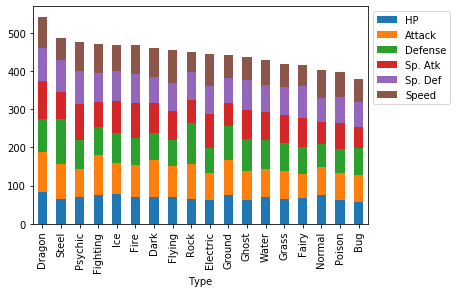

```python
means_by_pokemon_type.loc[:, means_by_pokemon_type.columns != "Total"].plot(kind = "bar", stacked = True).legend(bbox_to_anchor=(1,1))
```

One interesting thing about this chart, which was organized in descending order from highest total average ability points to lowest, is that Dragon types have the highest average number of ability points ant Bug types have the lowest average number of ability points. This begs the question, are Dragons overrepresented because the type pairs with many other types or do they have more stats because they also tend to be legendary pokemon? Are bug types weaker because they have strengths in other areas, or is it because they get special moves that need to be balanced with weaker ability point distributions?

Overall, the difference in averages is not very high when you compare them to the total average number of ability points a Pokemon gets. Some Pokemon, like Steel types, get a very high defense, however that power is offset with a lower average speed. It appears that the designers wanted to make differences between the types and they represent that power by offering some types higher particular stats compared to their others. However, because they do not want to make certain types extremely strong, they keep the average total number of points around the same level so that one type does not become the de facto strongest because it's counter is weaker regarding ability stats.

### Q6. For 15 Points: Explore how the Pokémon in each generation differ from each other?

- Do you think designers of *Pokémon* tried to address different distributions of ability points in each generation?

```python
legendaries = pokemon_data[["Generation", "Legendary"]].groupby("Generation")["Legendary"].value_counts().to_frame().unstack()
legendaries
```

| Legendary Generation | Legendary False | Legendary True |
| --- | --- | --- |
| 1 | 160 | 6 |
| 2 | 101 | 5 |
| 3 | 142 | 18 |
| 4 | 108 | 13 |
| 5 | 150 | 15 |
| 6 | 74 | 8 |

Legendary Pokemon generally have higher stat allocations than their non legendary counterparts, so looking at the number of legendary Pokemon by generation gives us some potential insight into what the developers were thinking across generations. From the above data frame, the peak number of legendary Pokemon in a generation was in generation 3 where 18 were introduced. However, the number of legendary Pokemon also generally scales with the number of new Pokemon introduced. The developers likely weren't concerned about the effects of legendaries after their initial increase between generation 2 and 3 as legendaries represent around 10% of the new Pokemon added to the game.

```python
gen_group_by = pokemon_data.loc[:, "Total":"Generation"].groupby("Generation")

gen_averages = gen_group_by.mean().reset_index()
gen_averages
```

|  | Generation | Total | HP | Attack | Defense | Sp. Atk | Sp. Def | Speed |
| --- | --- | --- | --- | --- | --- | --- | --- | --- |
| 0 | 1 | 426.813253 | 65.819277 | 76.638554 | 70.861446 | 71.819277 | 69.090361 | 72.584337 |
| 1 | 2 | 418.283019 | 71.207547 | 72.028302 | 73.386792 | 65.943396 | 73.905660 | 61.811321 |
| 2 | 3 | 436.225000 | 66.543750 | 81.625000 | 74.100000 | 75.806250 | 71.225000 | 66.925000 |
| 3 | 4 | 459.016529 | 73.082645 | 82.867769 | 78.132231 | 76.404959 | 77.190083 | 71.338843 |
| 4 | 5 | 434.987879 | 71.787879 | 82.066667 | 72.327273 | 71.987879 | 68.739394 | 68.078788 |
| 5 | 6 | 436.378049 | 68.268293 | 75.804878 | 76.682927 | 74.292683 | 74.890244 | 66.439024 |

Looking at the stat averages by generation, it is difficult to see a clear concern for the distribution of ability points across generations. From the data frame above, we see that generation 4 Pokemon are on average stronger than other generations when comparing their ability point distributions. For any pokemon pulled from generation 4, you are more likely to have higher ability points when comparing that pokemon with a randomly pulled pokemon from any other generation.